# 14 Joint Variability

# 1 Variance, Covariance

In previous chapters we introduced you to the **variance** as a measure of *spread* of a distribution:

$$\text{Var}[X] = \text{E}\big[ (X - \text{E}[X] )^2 \big]$$

i.e. the variance is the expected value of the squared deviations from the mean. The variance can also be written as a sum:

$$\sigma^2 = \frac 1n \sum_i^n (X_i - \bar X)^2 \hspace{1cm} s^2 = \frac{1}{n-1} \sum_i^n (X_i - \bar X)^2$$

where $\sigma^2$ denotes the population variance and $s^2$ denotes the sample variance.

Variance is useful for characterizing the spread of one-dimensional data (i.e. a single variable). When dealing with multidimensional data (i.e. many variables) we’re often interested in characterizing the *dependency* (i.e. association) between two variables, i.e. the tendency for variables to vary *together*. We already introduced you to *correlation* as a measure of the strength of the linear association between two variables. We’ll now introduce the concept of dependence more formally.

**Covariance** is a measure of the *joint variability* of two variables—it gives the extent to which two variables tend to vary *in the same direction*.

Conceptually, covariance is similar to correlation. If two variables have a positive association, covariance is positive; if they have a negative association, covariance is negative. The difference between covariance and correlation is in their *units*—this point will become clear in the next section.

Formally, the covariance of two variables $X$ and $Y$ is defined:

$$\text{Cov}[X,Y] = \text{E}\big[ (X - \text{E}[X]) (Y - \text{E}[Y] )\big]$$

Or, written as a sum:

$$\sigma_{XY} = \frac 1n \sum_i^n (X_i - \bar X)(Y_i - \bar Y) \hspace{1cm} s_{XY} = \frac{1}{n-1} \sum_i^n (X_i - \bar X)(Y_i - \bar Y)$$

where $\sigma_{XY}$ denotes the population covariance and $s_{XY}$ denotes the sample covariance.

In R you can compute the covariance between two variables using `cov()`. Below is a plot of the relationship between temperature and albedo from the NYC heatwave data:

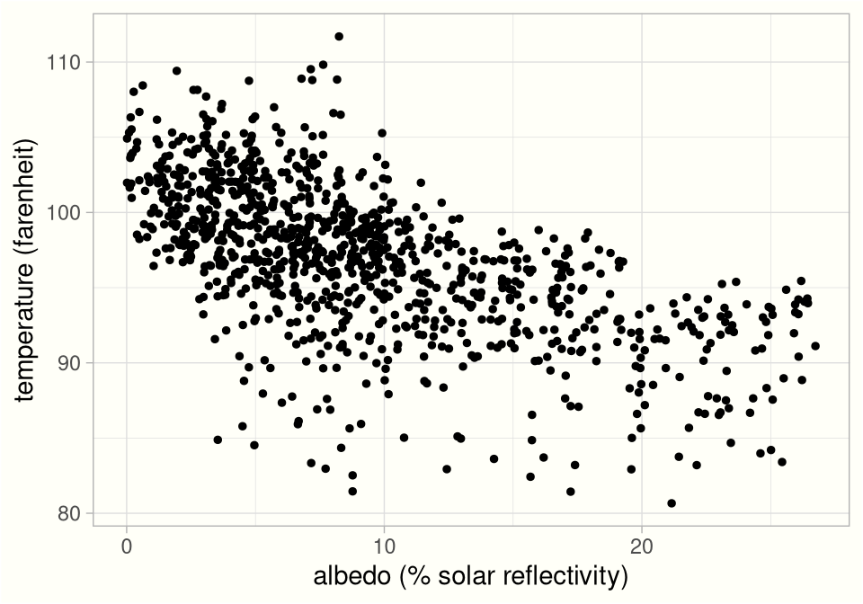

```r
cov(nycheat$temperature, nycheat$albedo)
```

```
## [1] -18.99705
```

The units of covariance is simply the product of the units of the two variables.

With a matrix of numeric variables, we can also construct a *covariance matrix* showing the pairwise covariances between each of the variables:

```r
vcov_table = cov(nycheat[ ,2:6])
kable(vcov_table)
```

|  | temperature | vegetation | albedo | building_height | pop_density |
| --- | --- | --- | --- | --- | --- |
| temperature | 25.2023494 | -0.4213865 | -18.9970471 | 5.0919835 | 5.168777e+03 |
| vegetation | -0.4213865 | 0.0216491 | 0.3142614 | -0.1574037 | -1.820730e-02 |
| albedo | -18.9970471 | 0.3142614 | 38.6188177 | -3.6195019 | -7.339874e+03 |
| building_height | 5.0919835 | -0.1574037 | -3.6195019 | 10.5018033 | -1.664037e+03 |
| pop_density | 5168.7771526 | -0.0182073 | -7339.8740999 | -1664.0374370 | 1.208001e+08 |

You may notice that the diagonal elements of this matrix appear to show the covariance of a variable with *itself*. As it turns out, the covariance of a variable with itself is simply its *variance*.

$$\text{Cov}[X,X] = \text{E}\big[ (X - \text{E}[X])(X - \text{E}[X]) \big] = \text{Var}[X]$$

For this reason the covariance matrix is also known as the *variance-covariace matrix*. Formally, the variance-covariance matrix is denoted $\boldsymbol \Sigma$. For the three RVs $X$, $Y$ and $Z$:

$$\boldsymbol \Sigma =
\begin{bmatrix}
\sigma^2_X & \sigma_{XY} & \sigma_{XZ} \\
\sigma_{YX} & \sigma^2_y & \sigma_{YZ} \\
\sigma_{ZX} & \sigma_{ZY} & \sigma^2_Z
\end{bmatrix}$$

Earlier in the course you may recall us saying that variance is only additive for *independent* RVs, i.e.

$$\text{Var}[X+Y] = \text{Var}[X]+\text{Var}[Y] \hspace{1cm} (\text{iff X & Y independent})$$

We can now show why this is the case. Using the fact that $\text{Var}[X] = \text{E}[X^2] - \text{E}[X]^2$, we can expand the $\text{Var}[X+Y]$ as follows:

$$\begin{aligned}
\text{Var}[X+Y] &= \text{E}\big[ (X+Y)^2 \big] - \text{E}[X+Y]^2 \\
&= \text{E}\big[ X^2 + 2XY + Y^2 \big] - \big( \text{E}[X]+\ \text{E}[Y] \big)^2 \\
&= \text{E}[X^2]+\text{E}[2XY]+E[Y^2] - \text{E}[X]^2 - 2\text{E}[X]E[Y] - \text{E}[Y]^2 \\
&= \big( \text{E}[X^2] - \text{E}[X]^2 \big) + \big( \text{E}[Y^2] - \text{E}[Y]^2 \big) + 2 \big(E[XY] - \text{E}[X]\text{E}[Y] \big) \\
&= \text{Var}[X] + \text{Var}[Y] + 2\text{Cov}[X,Y]
\end{aligned}$$

i.e. the variance of a sum of RVs has a *third* term that accounts for the *dependency* of the two variables. Naturally, if the variables are independent, they have zero covariance, and the expression for variance reduces to the simple two-term sum.

# 2 Correlation

**Correlation** solves this issue by dividing covariance by the standard deviations of each of the variables. Formally, the correlation between two variables $X$ and $Y$ is defined:

$$\text{Cor}[X,Y] = \frac{\text{E}\big[ (X - \text{E}[X]) (Y - \text{E}[Y] )\big]}{\sigma_X \sigma_Y}$$

Or, written as a sum:

$$\rho_{XY} = \frac 1n \frac{\sum_i^n (X_i - \bar X)(Y_i - \bar Y)}{\sigma_X \sigma_Y} \hspace{1cm} r_{XY} = \frac{1}{n-1} \frac{\sum_i^n (X_i - \bar X)(Y_i - \bar Y)}{s_X s_Y}$$

where $\rho_{XY}$ denotes the population correlation and $r_{XY}$ denotes the sample correlation. Note this particular definition of correlation is known as **Pearson’s product-moment correlation coefficient**, or PPMCC, as the cool kids say.

Correlation is a *unitless* quantity—it effectively *normalizes* covariance, reducing it to a quantity between -1 and 1, making it possible to compare the *strength* of the joint variability (dependence) between sets of two variables.

In R you can use `cor()` to compute correlation coefficient between two variables:

```r
cor(nycheat$temperature, nycheat$albedo)
```

```
## [1] -0.6089282
```

Below is a correlation matrix for the variables in the NYC heatwave dataset:

```r
cor_table = cor(nycheat[ ,2:6])
kable(cor_table)
```

|  | temperature | vegetation | albedo | building_height | pop_density |
| --- | --- | --- | --- | --- | --- |
| temperature | 1.0000000 | -0.5704794 | -0.6089282 | 0.3129929 | 0.0936772 |
| vegetation | -0.5704794 | 1.0000000 | 0.3436937 | -0.3301132 | -0.0000113 |
| albedo | -0.6089282 | 0.3436937 | 1.0000000 | -0.1797287 | -0.1074622 |
| building_height | 0.3129929 | -0.3301132 | -0.1797287 | 1.0000000 | -0.0467194 |
| pop_density | 0.0936772 | -0.0000113 | -0.1074622 | -0.0467194 | 1.0000000 |

Since correlation is unitless, we can directly compare the correlations between different sets of variables (e.g. we can say the correlation between `temperature` and `building_height` is stronger than the correlation between `temperature` and `pop_density`. Note how we cannot do this with the covariance matrix.)

Note that correlation (and covariance) are only receptive to *linear* relationships between variables. Below are some examples of scatterplots showing different kinds of association between two variables:

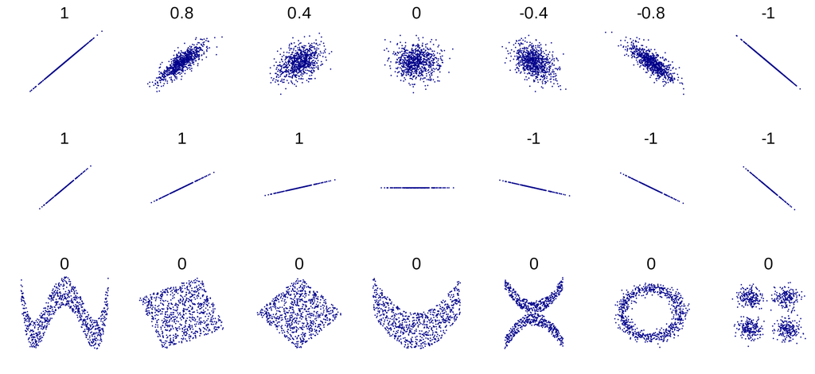

The bottom row shows examples of *nonlinear* associations. Though these variables are clearly associated, they have zero correlation.

# 3 Multivariate Normal

We introduced the normal distribution in chapter 9, as the continuous probability distribution with the density function:

$$\text{pdf}(X) = \frac{1}{\sqrt{2\pi\sigma^2}}e^{-(X-\mu)^2/2\sigma^2}$$

Sometimes this is known as the **univariate** normal distribution, since it’s a function of one random variable, $X$.

Often in statistics we must deal with a *combination* of random variables (e.g. in multiple regression). In these situations we can generalize the simple normal distribution to higher dimensions—this is known as the **multivariate normal** or **joint normal** distribution.

Consider a random vector ${\boldsymbol X} = ({\boldsymbol X}_1, {\boldsymbol X}_2, ..., {\boldsymbol X}_k)$, which is a collection of $k$ random variables. This random vector is multivariate normal if every linear combination of its RVs is normally distributed, e.g. if

$$a_1 {\boldsymbol X}_1 + a_2 {\boldsymbol X}_2 + ... + a_k {\boldsymbol X}_k$$

has a normal distribution for each of the constants $a_1, a_2, ...$ etc.

The random vector ${\boldsymbol X}$ is said to have mean vector ${\boldsymbol \mu}$ and covariance matrix ${\boldsymbol \Sigma}$:

$${\boldsymbol \mu }= \big[ \text{E}[X_1], \text{E}[X_2], ..., \text{E}[X_k] \big]$$

$${\boldsymbol \Sigma }=
\begin{bmatrix}
\sigma^2_{X_1} & \sigma_{X_1,X_2} & ... & \sigma_{X_1,X_k} \\
\sigma_{X_2,X_1} & \sigma^2_{X_2} & ... & \sigma_{X_2,X_k} \\
\vdots & \vdots & \ddots & \vdots \\
\sigma_{X_k, X_1} & \sigma_{X_k, X_2} & ... & \sigma^2_{X_k}
\end{bmatrix}$$

Its *joint* probability density function is:

$$\frac{1}{\sqrt{(2\pi)^k | {\boldsymbol \Sigma }|}} \exp\big(-\tfrac 12 ({\boldsymbol X} - {\boldsymbol \mu})^T {\boldsymbol \Sigma}^{-1} ({\boldsymbol X} -{\boldsymbol \mu}) \big)$$

Which can be expressed using the following shorthand:

$${\boldsymbol X} \sim \mathcal N \big( {\boldsymbol \mu}, {\boldsymbol \Sigma }\big)$$

Example—consider the random vector ${\boldsymbol X} = (X_1, X_2)$, which is bivariate normal with mean vector ${\boldsymbol \mu }= \big[\begin{smallmatrix} 2 \\ 1 \end{smallmatrix} \big]$ and covariance matrix ${\boldsymbol \Sigma }= \big[ \begin{smallmatrix} 1 \\ 0 \end{smallmatrix} \begin{smallmatrix} 0 \\ 1.5 \end{smallmatrix} \big]$ (i.e. $X_1$ and $X_2$ are uncorrelated). Below is a plot showing the 3D bivariate normal for $X_1$ and $X_2$, overlaid on a heatmap:

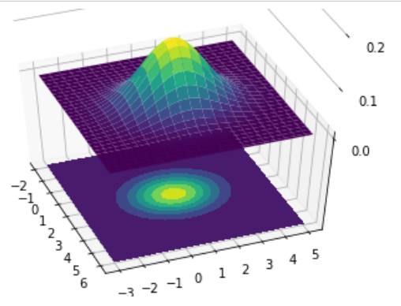

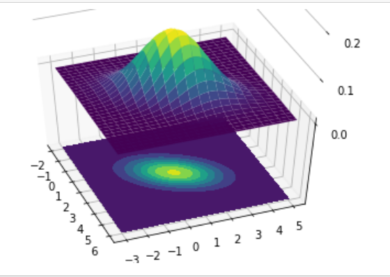